# Лабораторная работа №2

Основы вероятностного моделирования угроз

Бабенко Артём Сергеевич

1032259400@rudn.ru

Российский университет дружбы народов

2026-08-28

## Докладчик

- Бабенко Артём Сергеевич
- студент группы НФИмд-01-25
- Российский университет дружбы народов
- 1032259400@rudn.ru
- https://github.com/artyombabenko

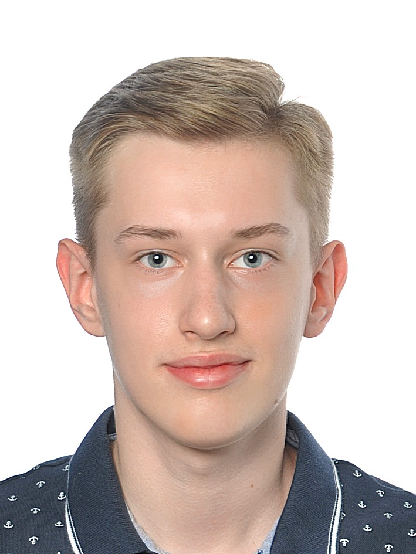

## Цель работы

Освоить базовые методы вероятностного моделирования случайных процессов в контексте кибербезопасности на примере моделирования потока атак на веб-сервер.

## Задачи

- Реализовать симуляцию пуассоновского потока атак.
- Выполнить статистический анализ результатов:
  - гистограмма числа атак за час;
  - накопленное число атак;
  - проверка экспоненциальности интервалов (QQ-plot);
  - оценка вероятности P(>10 атак за час).
- Исследовать сходимость оценки вероятности от объёма выборки.
- Провести параметрическое исследование по λ.
- Преобразовать код в литературный стиль и сгенерировать производные форматы.

## Выполнение работы. Подготовка проекта

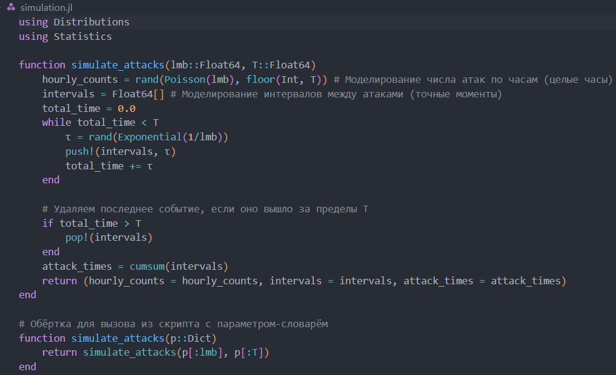

Рисунок 1: Скрипт src/simulation.jl

## Выполнение работы. Подготовка проекта

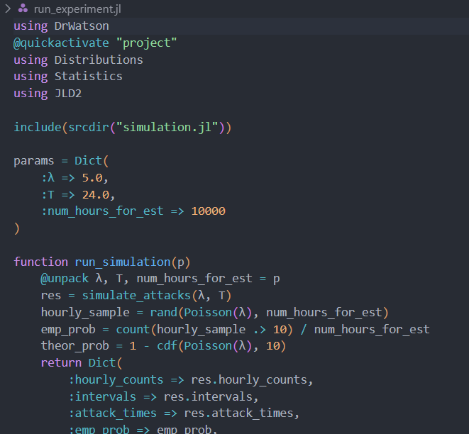

Рисунок 2: Скрипт scripts/run_experiment.jl

## Выполнение работы. Подготовка проекта

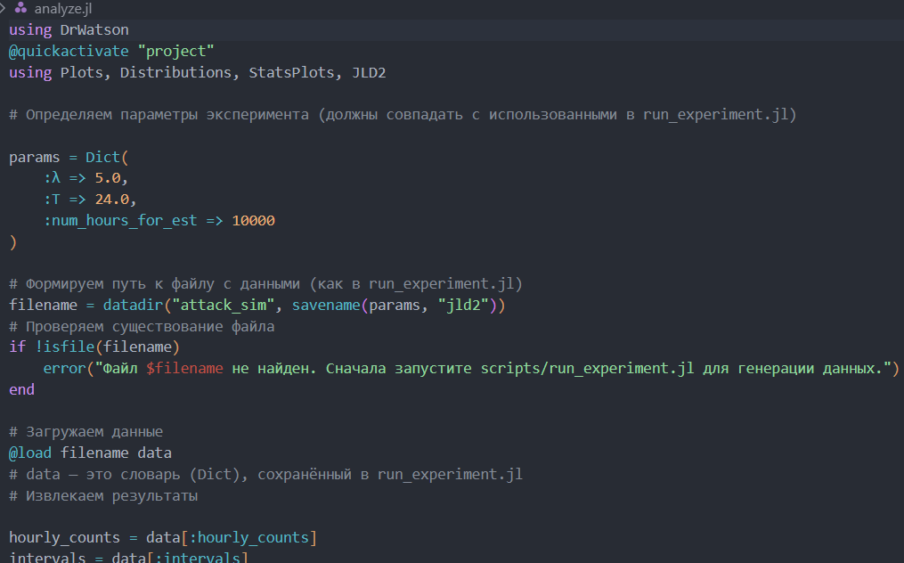

Рисунок 3: Скрипт scripts/analyze.jl

## Выполнение работы. Подготовка проекта

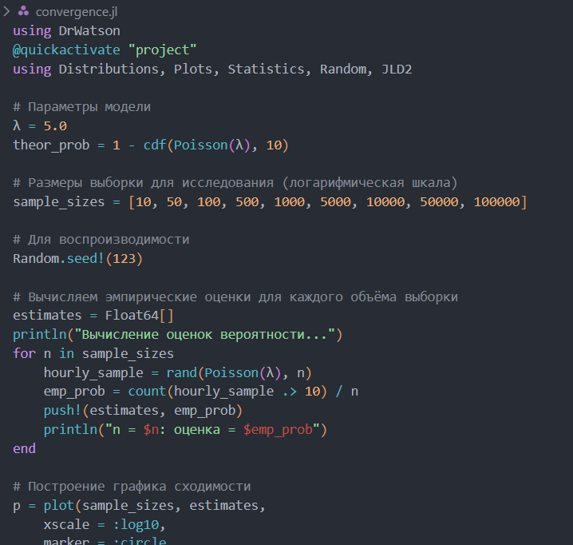

Рисунок 4: Скрипт scripts/convergence.jl

## Выполнение работы. Подготовка проекта

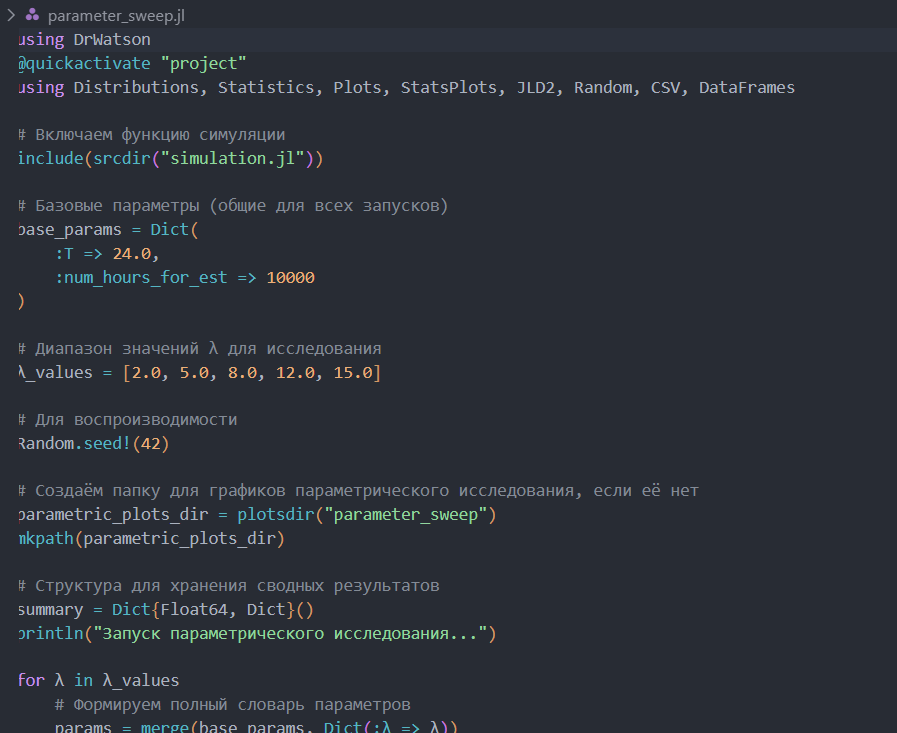

Рисунок 5: Скрипт scripts/parameter_sweep.jl

## Выполнение работы. Генерация производных форматов

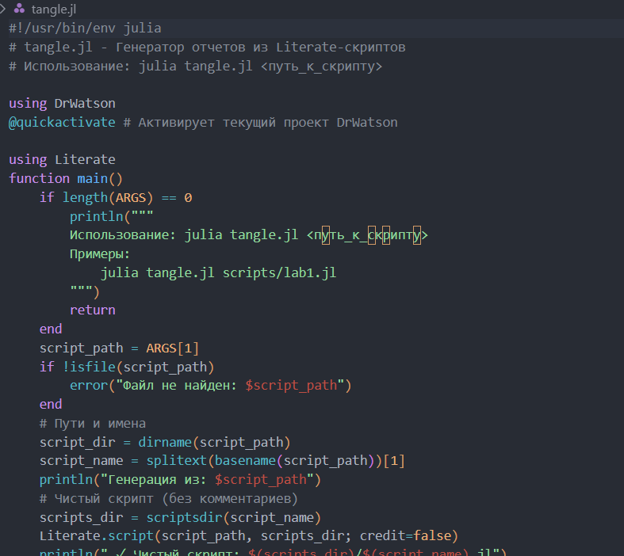

Рисунок 6: Скрипт для генерации производных форматов tangle.jl

## Выполнение работы. Генерация производных форматов

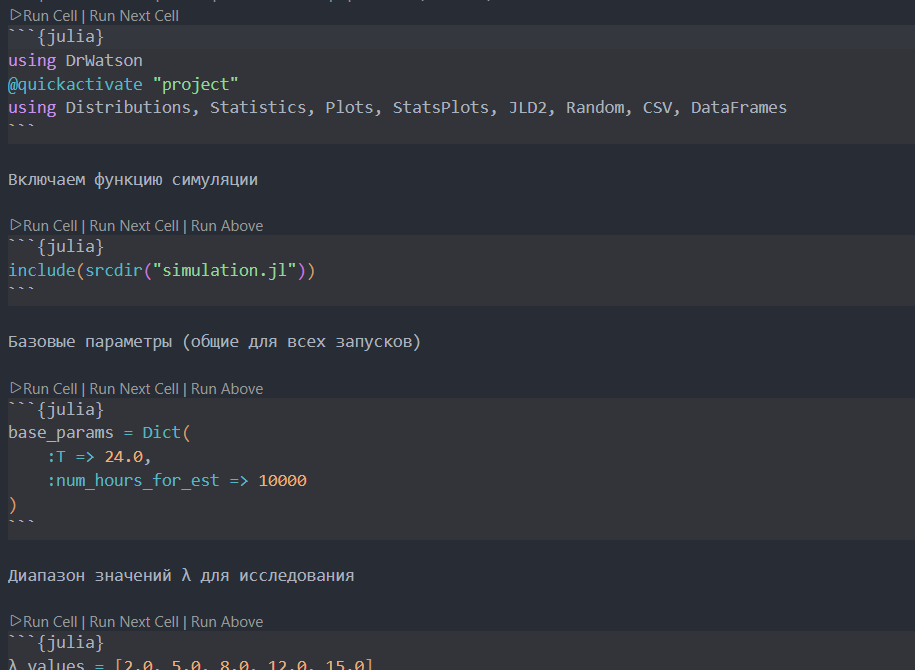

Рисунок 7: Формат qmd

## Выполнение работы. Генерация производных форматов

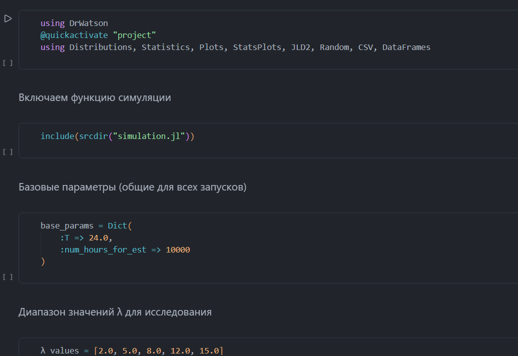

Рисунок 8: Формат ipynb

## Детальные графики

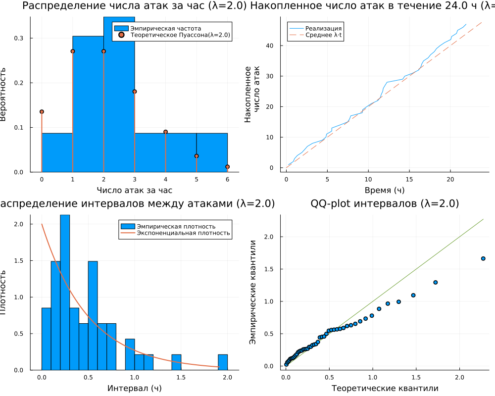

Рисунок 9: Детальные графики

## Детальные графики

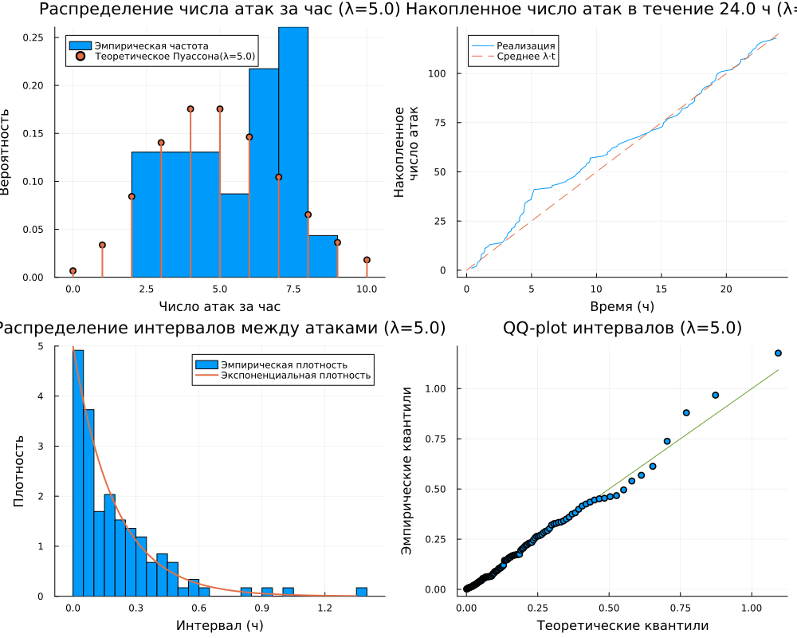

Рисунок 10: Детальные графики

## Детальные графики

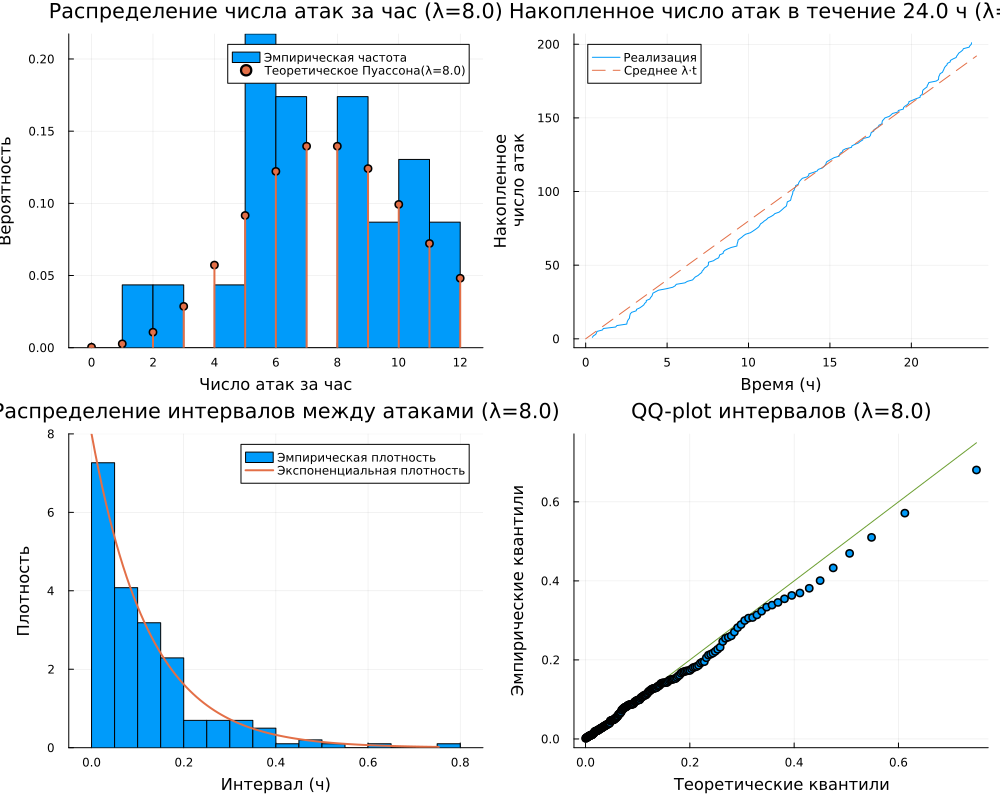

Рисунок 11: Детальные графики

## Детальные графики

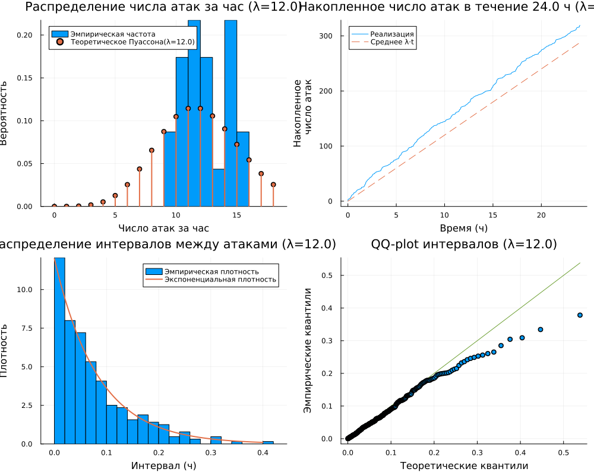

Рисунок 12: Детальные графики

## Детальные графики

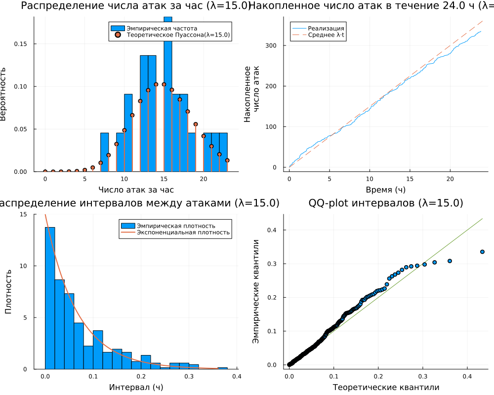

Рисунок 13: Детальные графики

## Выводы

1. Сформирована структура рабочего пространства на основе DrWatson с разделением исходных кодов, данных и документации.
2. Реализована симуляция пуассоновского потока атак двумя способами: почасовые счётчики и точные моменты через экспоненциальные интервалы.
3. Выполнен статистический анализ: гистограммы, накопленный график, QQ-plot подтверждают соответствие теоретическим распределениям.
4. Проведено параметрическое исследование: при росте λ от 2 до 15 вероятность P(>10) возрастает от ~0 до ~0.88.
5. Исследована сходимость оценки вероятности редкого события: для надёжной оценки при λ=5 необходим объём выборки порядка 10 000–100 000 часов.
6. Из литературного кода автоматически сгенерированы три формата: чистый скрипт, Jupyter Notebook и документ Quarto.

## Список литературы

1. JuliaLang [Электронный ресурс]. 2024 JuliaLang.org contributors. URL: https://julialang.org/ (дата обращения: 11.10.2024).
2. Literate.jl Documentation [Электронный ресурс]. Fredrik Ekre. URL: https://fredrikekre.github.io/Literate.jl/v2/ (дата обращения: 11.10.2024).
3. DrWatson.jl Documentation [Электронный ресурс]. JuliaDynamics. URL: https://juliadynamics.github.io/DrWatson.jl/stable/ (дата обращения: 11.10.2024).